# Gene Set Enrichement and Network Analysis

### 3.2.3 GSEA Results

Since we performed GSEA manually (details discussed in the [journal](https://github.com/bcb420-2023/Jielin_Yang/wiki/Gene-Set-Enrichment-and-Network-Analysis)), we will import the results from the `GSEA` software.

```r
# Import GSEA results for VTP vs Control Since R is having problem correctly
# parsing the tab in the tsv files, we have manually converted the results into
# a csv file to change the delimiters Detailed description documented in the
# journal
vtp_ctrl_gsea_upreg <- read.csv("./Data/VTPControlPreranked/gsea_report_for_na_pos_1680148985575.csv",
    header = TRUE)
vtp_ctrl_gsea_downreg <- read.csv("./Data/VTPControlPreranked/gsea_report_for_na_neg_1680148985575.csv",
    header = TRUE)
```

Our GSEA analysis identified `2282` out of `5256` specified gene sets associated with the upregulated genes in the VTP treatment condition. Of these, `503` gene sets were significantly enriched (FDR < 0.25) with an average enrichment score of `0.54`. This signficance threshold was chosen in accordance with the default GSEA setting.<sup>10</sup>

Table 1 shows the enriched gene sets with the corresponding enrichment score and FDR q value. The top enriched processes are related to mitocondrial functions, including mitochondrial translation as well as biological processes related to ribosomal functions. The enriched biological processes shows that the VTP treatment may be associated with an dystregualtion of metabolic processes in the cells.

```r
# Filter and prepare the table for display
upreg_table <- vtp_ctrl_gsea_upreg %>%
    dplyr::select(NAME, SIZE, ES, FDR.q.val) %>%
    dplyr::rename(`Gene Set` = NAME, Size = SIZE, `Enrichment Score` = ES, `FDR q-value` = FDR.q.val) %>%
    # Extract the gene set name, round the enrichment score and FDR q-value
dplyr::mutate(`Gene Set` = stringr::str_remove(`Gene Set`, "%.*$")) %>%
    # Convert the gene set name to sentence case
dplyr::mutate(`Gene Set` = stringr::str_to_sentence(`Gene Set`)) %>%
    # Sort the table by FDR q-value
dplyr::arrange(`FDR q-value`) %>%
    # Select significantly enriched gene sets
dplyr::filter(`FDR q-value` < 0.25)

# Display the table
DT::datatable(upreg_table, rownames = FALSE, filter = "top", options = list(ppageLength = 10,
    scrollX = TRUE)) %>%
    # Changing the font size of content
DT::formatStyle(names(upreg_table), fontSize = "12px")
```

| Gene Set | Size | Enrichment Score | FDR q-value |
| --- | --- | --- | --- |
| Mitochondrial translation elongation | 86 | 0.6780297 | 0 |
| Rrna processing | 195 | 0.60570717 | 0 |
| Mitochondrial translation | 107 | 0.6469687 | 0 |
| Mitochondrial translation initiation | 87 | 0.6767272 | 0 |
| Major pathway of rrna processing in the nucleolus and cytosol | 177 | 0.61149174 | 0 |
| Rrna processing in the nucleus and cytosol | 186 | 0.6088941 | 0 |
| Mitochondrial translation termination | 87 | 0.67043483 | 0 |
| Mitochondrial translation | 92 | 0.6686541 | 0 |
| Rrna processing | 157 | 0.6093675 | 0 |
| Rrna metabolic process | 183 | 0.5967197 | 0 |

[output cut: 493 more lines]

**Table 1.** Enriched gene sets in the upregulated genes under VTP treatment.

Furthermore, GSEA has also identified `2974` gene sets associated with the downregulated genes in the VTP. Of these, `1364` gene sets were significantly enriched (FDR < 0.25). The average enrichment score for these downregulated gene sets is `-0.51`. There are more enriched gene sets identified in the downregulated genes compared to the upregulated genes, which is expected since VTP is an inhibitor of the transcritpional activator complex YAP/TAZ.<sup>1</sup> As shown in Table 2, the top enriched gene sets are related to integrin and collagen formaiton pathways. Since both are major components of the extracellular matrix as well as cell adhesion, these enrichment results suggest that the VTP has an effect on downregulating the processes involved in fibrosis formation.

```r
# Filter and prepare the table for display
downreg_table <- vtp_ctrl_gsea_downreg %>%
    dplyr::select(NAME, SIZE, ES, FDR.q.val) %>%
    dplyr::rename(`Gene Set` = NAME, Size = SIZE, `Enrichment Score` = ES, `FDR q-value` = FDR.q.val) %>%
    dplyr::mutate(`Gene Set` = stringr::str_remove(`Gene Set`, "%.*$")) %>%
    dplyr::mutate(`Gene Set` = stringr::str_to_sentence(`Gene Set`)) %>%
    dplyr::arrange(`FDR q-value`) %>%
    dplyr::filter(`FDR q-value` < 0.25)

# Display the table
DT::datatable(downreg_table, rownames = FALSE, filter = "top", options = list(ppageLength = 10,
    scrollX = TRUE)) %>%
    DT::formatStyle(names(downreg_table), fontSize = "12px")
```

| Gene Set | Size | Enrichment Score | FDR q-value |
| --- | --- | --- | --- |
| Beta1 integrin cell surface interactions | 57 | -0.73359644 | 0 |
| Non-integrin membrane-ecm interactions | 39 | -0.7673077 | 0 |
| Pid_integrin1_pathway | 42 | -0.74991846 | 0 |
| Collagen formation | 66 | -0.6845758 | 0 |
| Hallmark_epithelial_mesenchymal_transition | 145 | -0.60434616 | 0 |
| Ecm proteoglycans | 36 | -0.7722841 | 0 |
| Collagen biosynthesis and modifying enzymes | 50 | -0.717752 | 0 |
| Beta3 integrin cell surface interactions | 37 | -0.7566827 | 0 |
| Extracellular structure organization | 123 | -0.5943899 | 0 |
| External encapsulating structure organization | 124 | -0.5961292 | 0 |

[output cut: 1354 more lines]

**Table 2.** Enriched gene sets in the downregulated genes under VTP treatment.

### 3.2.4 Comparative analysis of GSEA and ORA

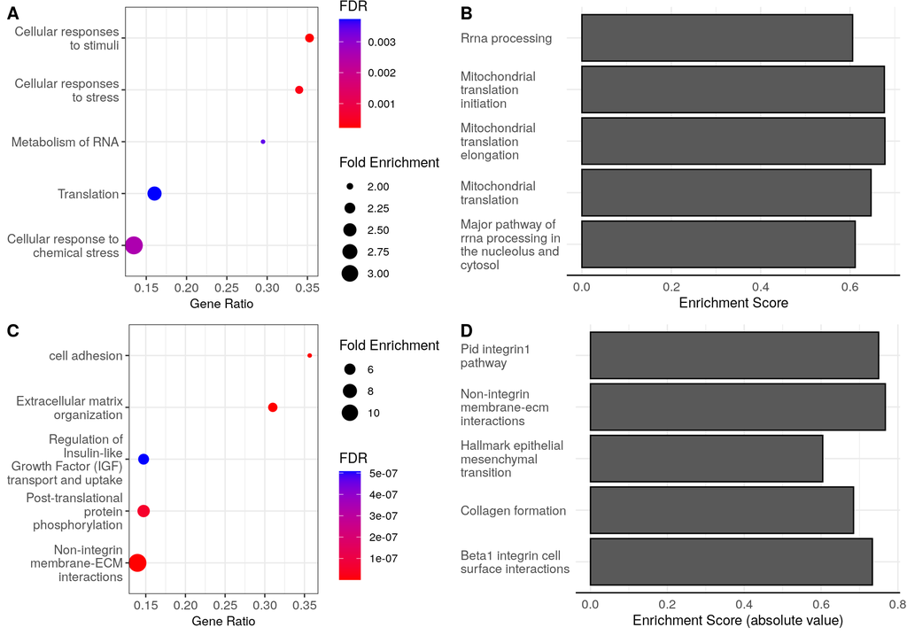

```r
# Top 5 enriched gene sets of upregulated genes, GSEA
gsea_up <- ggplot2::ggplot(upreg_table[1:5,], aes(x = `Enrichment Score`,
    y = stringr::str_wrap(`Gene Set`, 20))) +
    geom_bar(stat = "identity", color = "black") + # Define border color
    labs(x = "Enrichment Score", y = NULL) +
    theme_minimal() +
    theme(axis.line.x = element_line(), # Add a solid line for the x-axis
        axis.text.x = element_text(size = 10), # Change the font size of axis labels
        axis.text.y.left = element_text(size = 10),
        axis.text.y = element_text(hjust = 0)) # Align y-axis labels to the left

# Top 5 enriched gene sets of downregulated genes, GSEA
downreg_table$`Gene Set` <- gsub("_", " ", downreg_table$`Gene Set`)  # Replace underscore with space
gsea_down <- ggplot2::ggplot(downreg_table[1:5,], aes(x = -`Enrichment Score`,
    y = stringr::str_wrap(`Gene Set`, 20))) +
    geom_bar(stat = "identity", color = "black") +
    labs(x = "Enrichment Score (absolute value)", y = NULL) +
    theme_minimal() +
    theme(axis.line.x = element_line(),
        axis.text.x = element_text(size = 10),
        axis.text.y.left = element_text(size = 10),
        axis.text.y = element_text(hjust = 0))

# We have previously generated the plot for the ORA results in Assignment 2,
# and we reuse it for clear comparison
cowplot::plot_grid(dot_plot_up, gsea_up, dot_plot_down, gsea_down,
    ncol = 2, nrow = 2, labels = "AUTO", rel_heights = c(1, 1))
```

**Figure 3.** Top 5 enriched gene sets identified by GSEA and ORA for the up- (A, B) and down-regulated (C, D) genes. Results from previous ORA was shown in A and C, with colour of the dots indicates significance level, and the size indicates the fold enrichment. B, D illustrate the top 5 enriched gene sets identified by GSEA, with the enrichment score on the x-axis. All GSEA results are coloured the same as all gene sets has a FDR q-value of 0 (up to the maximum signficant figure).

However, such qualitative comparason between the results from GSEA and ORA are neither straitforward nor conclusive. In this case, we have to compare top enriched gene sets to access the consistency between the most significant results. However, in both types of analysis, both the order of the significance value as well as the effect sizes (enrichment score and fold enrichment. respectively) also critically effect our interpretation of the results. By qualitatively comparing them, it is unlikely for human eyes to identify the hierarchical structure returned by the two types of analysis, especially when it comes to gene sets beyond the first few top enrichments.

## 3.3 Effect of VTP treatment under TGF-β1

Since the authors of the original publication also investigated whether the effect of VTP is preseved even under the profibrotic environment, we also performed GSEA based on the differential gene expression analysis results comparing the VTP-treated cardiac stromal cells and control under TGF-β1 treatment.

### 3.3.1 Data Preparation

While there are not many differntially expressed genes in this dataset, we calcualted the rank of each gene similarly to the previous analysis.

```r
# Add row names as a column for naming purpose
deg_vtp_tgf$GeneName <- rownames(deg_vtp_tgf)

# Constructing ranked gene list
deg_vtp_tgf$rank <- (-log(deg_vtp_tgf$PValue, base = 10)) * sign(deg_vtp_tgf$logFC)
deg_vtp_tgf_ranked <- dplyr::select(deg_vtp_tgf, GeneName, rank) %>%
    arrange(desc(rank)) %>%
    dplyr::select(GeneName, rank)

# Save the ranked gene list
write.table(deg_vtp_tgf_ranked, file = "./Data/vtp_tgf.rnk", sep = "\t", col.name = TRUE,
    row.names = FALSE, quote = FALSE)
```